# Session 05: Exploratory Data Analysis

326.212 전산통계 및 실습

## Variation / Covariation

*Variation describes the behavior within a variable, covariation describes the behavior between variables.*

- You should see your data in different viewpoints (or using different methods). If their results are not consistent with each other or even with what you think, then you should make sure why.
- Available methods : `geom_point`, `geom_hex` (continuous vs continuous), `geom_histogram` (continuous), `geom_boxplot` (categorical vs continuous), `geom_bar` (categorical), etc…

### 1. Scatter plot

```r
library(tidyverse)
#install.packages("GGally")
library(GGally)
as_tibble(iris[,c(1,2,5)])
```

```
## # A tibble: 150 × 3
##    Sepal.Length Sepal.Width Species
##           <dbl>       <dbl> <fct>
##  1          5.1         3.5 setosa
##  2          4.9         3   setosa
##  3          4.7         3.2 setosa
##  4          4.6         3.1 setosa
##  5          5           3.6 setosa
##  6          5.4         3.9 setosa
##  7          4.6         3.4 setosa
##  8          5           3.4 setosa
##  9          4.4         2.9 setosa
## 10          4.9         3.1 setosa
## # ℹ 140 more rows
```

- `summary` function contains abundant infomation of the data.

```r
summary(iris[,c(1,2,5)])
```

```
##   Sepal.Length    Sepal.Width          Species
##  Min.   :4.300   Min.   :2.000   setosa    :50
##  1st Qu.:5.100   1st Qu.:2.800   versicolor:50
##  Median :5.800   Median :3.000   virginica :50
##  Mean   :5.843   Mean   :3.057
##  3rd Qu.:6.400   3rd Qu.:3.300
##  Max.   :7.900   Max.   :4.400
```

- Draw a pairwise plot matrix using `ggpairs` of `iris` data.

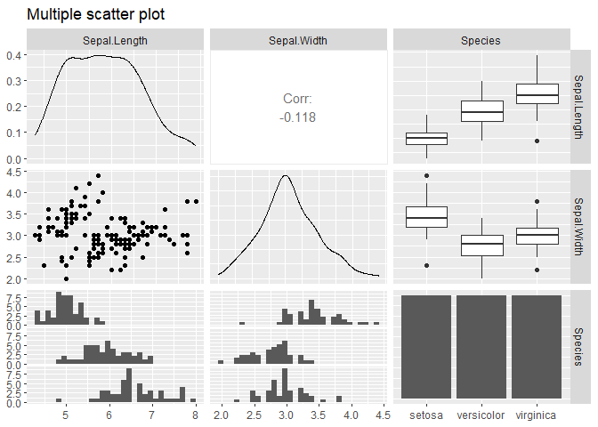

```r
ggpairs(data = iris[,c(1,2,5)],
        title = "Multiple scatter plot",
        progress = FALSE)
```

- What’s on the upper/lower matrix and diagonal part? What type of plot is given on each part depending on classes of two variables on each axis (`numeric` vs `numeric`, `numeric` vs `factor`)?
- `factor` vs `factor` : …?
- Note that there are many variations (Do ?ggpairs !)
- How can you recover this plot?

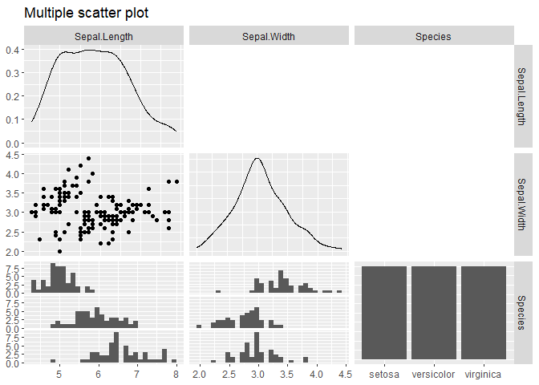

```r
ggpairs(data = iris[,c(1,2,5)],
        title = "Multiple scatter plot",
        upper = list(continuous = "blank", combo = "blank"),
        progress = FALSE)
```

- What about this?

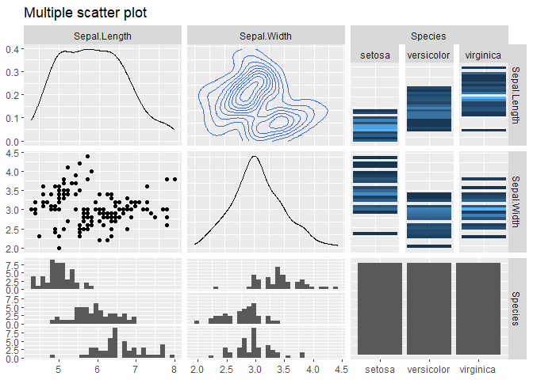

```r
ggpairs(data = iris[,c(1,2,5)],
        title = "Multiple scatter plot",
        upper = list(continuous = "density", combo = "denstrip"),
        progress = FALSE)
```

### 2. Correlation plot

```r
#install.packages("corrplot")
library(corrplot)
```

- Correlation is a measure that shows a linear relationship between two continuous variables.
- How to compute a covariance/correlation matrix of $p$ variables?
- If you can get the $3\times 3$ correlation matrix of `iris[,1:3]`, then we can produce the following figure using `corrplot`.

```r
as_tibble(iris[,1:3])
```

```
## # A tibble: 150 × 3
##    Sepal.Length Sepal.Width Petal.Length
##           <dbl>       <dbl>        <dbl>
##  1          5.1         3.5          1.4
##  2          4.9         3            1.4
##  3          4.7         3.2          1.3
##  4          4.6         3.1          1.5
##  5          5           3.6          1.4
##  6          5.4         3.9          1.7
##  7          4.6         3.4          1.4
##  8          5           3.4          1.5
##  9          4.4         2.9          1.4
## 10          4.9         3.1          1.5
## # ℹ 140 more rows
```

```r
summary(iris[,1:3])
```

```
##   Sepal.Length    Sepal.Width     Petal.Length
##  Min.   :4.300   Min.   :2.000   Min.   :1.000
##  1st Qu.:5.100   1st Qu.:2.800   1st Qu.:1.600
##  Median :5.800   Median :3.000   Median :4.350
##  Mean   :5.843   Mean   :3.057   Mean   :3.758
##  3rd Qu.:6.400   3rd Qu.:3.300   3rd Qu.:5.100
##  Max.   :7.900   Max.   :4.400   Max.   :6.900
```

```r
cor_iris <- cor(iris[,1:3]); cor_iris
```

```
##              Sepal.Length Sepal.Width Petal.Length
## Sepal.Length    1.0000000  -0.1175698    0.8717538
## Sepal.Width    -0.1175698   1.0000000   -0.4284401
## Petal.Length    0.8717538  -0.4284401    1.0000000
```

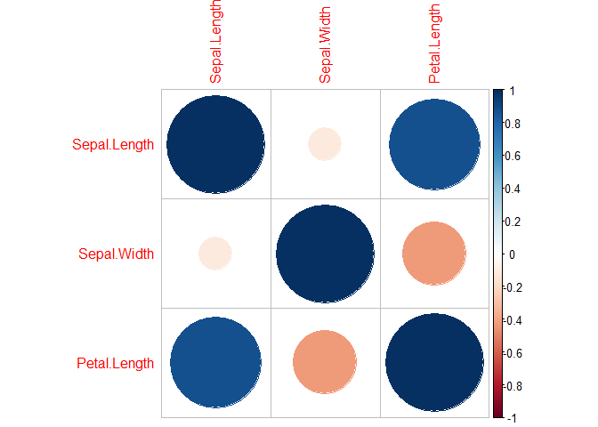

```r
corrplot(cor_iris)
```

- Note that there are many variations. (Again, Do ?corrplot !)

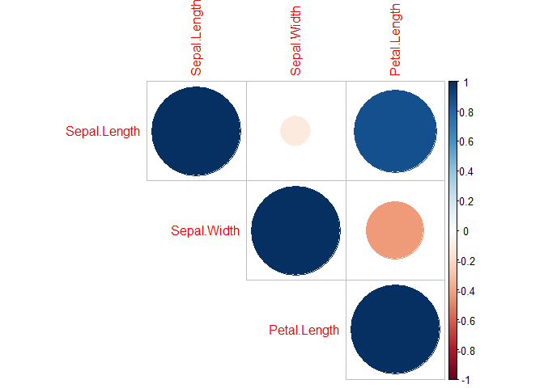

```r
corrplot(cor_iris, type = "upper")
```

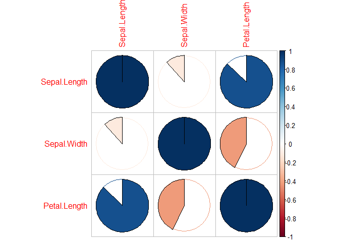

```r
corrplot(cor_iris, method = "pie")
```

### 3. Heatmap

- Heatmap can be thought as a generalization of a correlation matrix plot.
- See an example plot:

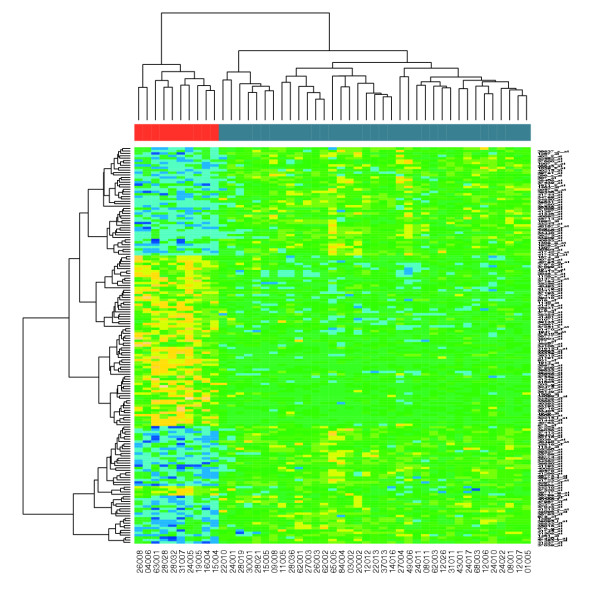

- Very good to visualize a large dimensional dataset. Here is a simple example.

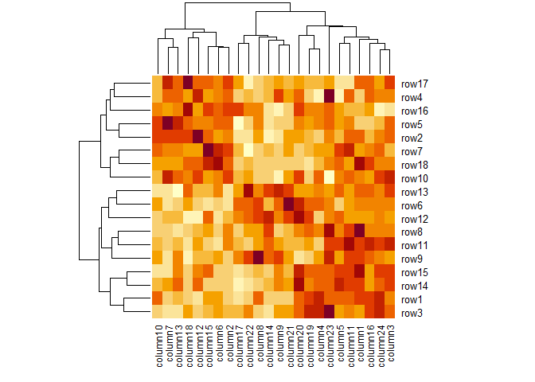

```r
set.seed(123)
nr1 = 4; nr2 = 8; nr3 = 6; nr = nr1 + nr2 + nr3
nc1 = 6; nc2 = 8; nc3 = 10; nc = nc1 + nc2 + nc3
mat = cbind(rbind(matrix(rnorm(nr1*nc1, mean = 1,   sd = 0.5), nr = nr1),
          matrix(rnorm(nr2*nc1, mean = 0,   sd = 0.5), nr = nr2),
          matrix(rnorm(nr3*nc1, mean = 0,   sd = 0.5), nr = nr3)),
    rbind(matrix(rnorm(nr1*nc2, mean = 0,   sd = 0.5), nr = nr1),
          matrix(rnorm(nr2*nc2, mean = 1,   sd = 0.5), nr = nr2),
          matrix(rnorm(nr3*nc2, mean = 0,   sd = 0.5), nr = nr3)),
    rbind(matrix(rnorm(nr1*nc3, mean = 0.5, sd = 0.5), nr = nr1),
          matrix(rnorm(nr2*nc3, mean = 0.5, sd = 0.5), nr = nr2),
          matrix(rnorm(nr3*nc3, mean = 1,   sd = 0.5), nr = nr3))
   )
mat = mat[sample(nr, nr), sample(nc, nc)] # random shuffle rows and columns
rownames(mat) = paste0("row", seq_len(nr))
colnames(mat) = paste0("column", seq_len(nc))

heatmap(mat)
```

- For more details, do Google!

## Missing values

- `summary` function contains abundant infomation of the data. Please execute `summary(airquality)` and see what you’ve got.

```r
as_tibble(airquality)
```

```
## # A tibble: 153 × 6
##    Ozone Solar.R  Wind  Temp Month   Day
##    <int>   <int> <dbl> <int> <int> <int>
##  1    41     190   7.4    67     5     1
##  2    36     118   8      72     5     2
##  3    12     149  12.6    74     5     3
##  4    18     313  11.5    62     5     4
##  5    NA      NA  14.3    56     5     5
##  6    28      NA  14.9    66     5     6
##  7    23     299   8.6    65     5     7
##  8    19      99  13.8    59     5     8
##  9     8      19  20.1    61     5     9
## 10    NA     194   8.6    69     5    10
## # ℹ 143 more rows
```

```r
summary(airquality)
```

```
##      Ozone           Solar.R           Wind             Temp
##  Min.   :  1.00   Min.   :  7.0   Min.   : 1.700   Min.   :56.00
##  1st Qu.: 18.00   1st Qu.:115.8   1st Qu.: 7.400   1st Qu.:72.00
##  Median : 31.50   Median :205.0   Median : 9.700   Median :79.00
##  Mean   : 42.13   Mean   :185.9   Mean   : 9.958   Mean   :77.88
##  3rd Qu.: 63.25   3rd Qu.:258.8   3rd Qu.:11.500   3rd Qu.:85.00
##  Max.   :168.00   Max.   :334.0   Max.   :20.700   Max.   :97.00
##  NA's   :37       NA's   :7
##      Month            Day
##  Min.   :5.000   Min.   : 1.0
##  1st Qu.:6.000   1st Qu.: 8.0
##  Median :7.000   Median :16.0
##  Mean   :6.993   Mean   :15.8
##  3rd Qu.:8.000   3rd Qu.:23.0
##  Max.   :9.000   Max.   :31.0
##
```

- This type of basic and preliminary analysis is fundamental and mandatory. See the result of `hist(airquality$Ozone)`. How do they deal with those missing values?

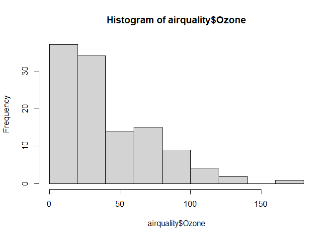

```r
hist(airquality$Ozone)
```

- In most cases, samples (or rows) having a missing value of any variable (or column) are removed before the analysis.
- For this purpose, `na.omit` is quite convinient to use. How many rows are left after using it?

```r
airquality %>% na.omit() %>% as.tbl()
```

```
## # A tibble: 111 × 6
##    Ozone Solar.R  Wind  Temp Month   Day
##    <int>   <int> <dbl> <int> <int> <int>
##  1    41     190   7.4    67     5     1
##  2    36     118   8      72     5     2
##  3    12     149  12.6    74     5     3
##  4    18     313  11.5    62     5     4
##  5    23     299   8.6    65     5     7
##  6    19      99  13.8    59     5     8
##  7     8      19  20.1    61     5     9
##  8    16     256   9.7    69     5    12
##  9    11     290   9.2    66     5    13
## 10    14     274  10.9    68     5    14
## # ℹ 101 more rows
```

- One may use `complete.cases`.

```r
sum(!complete.cases(airquality))
```

```
## [1] 42
```

- Note that this removal could be considered strict since it may lose some information.

## Exercise

Get the `flight` data from `nycflights13` package. This data set is the Airline on-time data for all flights departing NYC in 2013. For more information about the dataset such as columns, please see: https://rdrr.io/cran/nycflights13/man/flights.html

```r
library(nycflights13)
library(tidyverse)

head(flights)
```

```
## # A tibble: 6 × 19
##    year month   day dep_time sched_dep_time dep_delay arr_time sched_arr_time
##   <int> <int> <int>    <int>          <int>     <dbl>    <int>          <int>
## 1  2013     1     1      517            515         2      830            819
## 2  2013     1     1      533            529         4      850            830
## 3  2013     1     1      542            540         2      923            850
## 4  2013     1     1      544            545        -1     1004           1022
## 5  2013     1     1      554            600        -6      812            837
## 6  2013     1     1      554            558        -4      740            728
## # ℹ 11 more variables: arr_delay <dbl>, carrier <chr>, flight <int>,
## #   tailnum <chr>, origin <chr>, dest <chr>, air_time <dbl>, distance <dbl>,
## #   hour <dbl>, minute <dbl>, time_hour <dttm>
```

##### Q1. Remove samples (or rows) having a missing value of any variable (or column). After then, make a new column which value is 1 if `arr_delay > 0` else 0. Based on the modified dataset, reproduce the following plot.

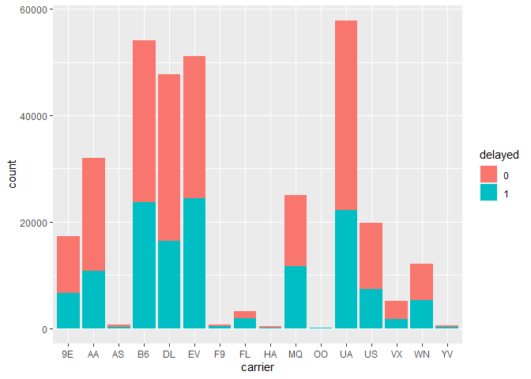

#### Q2. Explain your insight from the plot.

**Acknowledgment** All contents in this note is based on the book “R for Data Science”, written by Grolemund & Wickham.